# Workplace stress in real time: Three parsimonious scales for the experience sampling measurement of stressors and strain at work

Supplementary material S2: Data pre-processing report

**Luca Menghini,$^1$ Massimiliano Pastore,$^2$ & Cristian Balducci$^1$**

$^1$Department of Psychology, University of Bologna, Bologna, Italy

$^2$Department of Developmental and Social Psychology, University of Padova, Padua, Italy

# Aims and contents

The document includes the R code used to pre-process the raw data collected with the Sensus Mobile app (Xiong et al., 2016) and the Typeform (Barcelona, Spain) platform for the study “Workplace stress in real time: Three parsimonious scales for the experience sampling measurement of stressors and strain at work”. Specifically, it covers the reading and integration of single raw data files, the recoding of the measured variables, and the anonymization of the sample to produce the GDPR-compliant data files used in the main analyses, accompanied with a data dictionary.

The following R packages are used in this document (see References section):

```r
# required packages
packages <- c("jsonlite","tcltk","mgsub","birk","dplyr","tidyr","labourR","data.table","magrittr","plyr")

# generate packages references
knitr::write_bib(c(.packages(), packages),"packagesDataProc.bib")

# # run to install missing packages
# xfun::pkg_attach2(packages, message = FALSE); rm(list=ls())
```

# 1. Data reading

Frist, we read the raw data files obtained with the experience sampling method `ESMdata` and the preliminary questionnaire `RETROdata`.

```r
# removing all objets from the workspace
rm(list=ls())

# setting system time zone to GMT (for consistent temporal synchronization)
Sys.setenv(tz="GMT")
```

## 1.1. ESM data

Here, the `readSurveyData()` function is used to read the raw JSON data saved by the Sensus Mobile app and downloaded from our private AWS S3 bucket to the `data.path` directory. The `probe.definition` argument is used to read the Probe Definition files downloaded from the Sensus Mobile app (*Protocol -> Probe -> Scripted Interaction -> Share definition*) to couple input IDs with input names (i.e., item labels).

**show `readSurveyData()`**

````r
readSurveyData <- function(data.path,probe.definition){ require(jsonlite); require(tcltk); options(digits.secs=3)

  # 1. Reading data
  # .......................................
  # listing files in data path
  paths = list.files(data.path,recursive=TRUE,full.names=TRUE,include.dirs=FALSE)
  # taking only variables of interest
  var.names <- c("ParticipantId","Timestamp","InputId","Response","RunTimestamp","SubmissionTimestamp",
                 "ScriptName","ProtocolId","$type")
  # dataframe creation and population
  data <- as.data.frame(matrix(nrow=0,ncol=9))
  colnames(data) <- var.names
  ScheduledTimestamp <- vector()
  pb <- tkProgressBar("(1/2) Data reading:", "Data reading %",0, 100, 0) # progress bar
  for(path in paths){ info <- sprintf("%d%% done", round(which(paths==path)/length(paths)*100))
    setTkProgressBar(pb, round(which(paths==path)/length(paths)*100), title=paste("(1/2) Data reading:",info),info)
    if(file.info(path)$size>0){ # read only Datum files (i.e., containing ScriptDatum, if > 0 Kb)
      new.data <- read_json(path,simplifyDataFrame=TRUE)
      if(class(new.data)=="data.frame" & !is.null(new.data$Response)){ # keep only files with information
        if(class(new.data$Response)=="data.frame"){ # sometimes responses are read as dataframe
          new.data$Response <- as.character(new.data$Response$`$values`)}
        data <- rbind(data,new.data[var.names])}}}
  close(pb)
  # no responses are saved when participant or input ID is not showed (those rows are removed)
  data <- data[!is.na(data$ParticipantId),]
  data <- data[!is.na(data$InputId),]
  # some other minor settings
  row.names(data) <- as.character(1:nrow(data))
  data$Timestamp <- as.POSIXct(data$Timestamp,format="%Y-%m-%dT%H:%M:%S")
  names(data)[9] <- "os" # $type as OS (android or iOS)
  data[,9] <- gsub("Sensus.Probes.User.Scripts.ScriptDatum, Sensus","",data[,9])

  # 2. Response Ids as Item labels (reported in Probe Definition file)
  # ...............................................................
  if(!is.na(probe.definition)){
    readProbe <- function(path){ # function to read Probe Definition files
      probedefinition <- read_json(path,simplifyDataFrame=TRUE) # first probe definition file
      # reading input labels of the first inputGroup
      inputs <- probedefinition$ScriptRunners$`$values`$Script$InputGroups$`$values`[[1]]$Inputs$`$values`[[1]]$Name
      # other protocol information
      infos <- probedefinition$ScriptRunners$`$values`$Script$InputGroups$`$values`[[1]]
      PROTOCOL <- data.frame(protocolName=probedefinition$Protocol$Name,protocolId=probedefinition$Protocol$Id,
                             scriptName=infos$Name,inputName=inputs,inputId=infos$Inputs$`$values`[[1]]$Id)
      # adding other InputGroups when more than one
      if(length(probedefinition$ScriptRunners$`$values`$Script$InputGroups$`$values`)>1){
        for(i in 2:length(probedefinition$ScriptRunners$`$values`$Script$InputGroups$`$values`)){
          inputs <- probedefinition$ScriptRunners$`$values`$Script$InputGroups$`$values`[[i]]$Inputs$`$values`[[1]]$Name
          infos <- probedefinition$ScriptRunners$`$values`$Script$InputGroups$`$values`[[i]]
          PROTOCOL <- rbind(PROTOCOL,data.frame(protocolName=probedefinition$Protocol$Name,
                                                protocolId=probedefinition$Protocol$Id,
                                                scriptName=infos$Name,inputName=inputs,
                                                inputId=infos$Inputs$`$values`[[1]]$Id)) }}
      return(PROTOCOL) }
    # listing files in probe.definition path
    paths = list.files(probe.definition,recursive=TRUE,full.names=TRUE,include.dirs=FALSE)
    PROTOCOL <- readProbe(paths[1])
    # adding other Probe Definition files when more than one
    if(length(list.files(probe.definition))>1){
      for(path in paths[2:length(paths)]){
        PROTOCOL2 <- readProbe(path)
        PROTOCOL <- rbind(PROTOCOL,PROTOCOL2) }}
    # using Probe Definition info to convert inputID to inputName
    pb <- tkProgressBar("(2/2) Data processing:", "Data processing %",0, 100, 0) # progress bar
    for(i in 1:nrow(data)){ info <- sprintf("%d%% done", round(i/nrow(data)*100))
    setTkProgressBar(pb, round(i/nrow(data)*100), title=paste("(2/2) Converting InputIDs to InputNames", info), info)
      for(j in 1:nrow(PROTOCOL)){ if(!is.na(data[i,3]) & data[i,3]==PROTOCOL[j,5]){
        data[i,3] <- as.character(PROTOCOL[j,4]) }}}
    close(pb) }

  # 3. Cleaning and unlisting Response data
  # ...............................................................
  # cleaning categorical items from Sensus system info
  data$Response <- gsub("list","",data$Response)
  data$Response <- gsub(paste("c","\\(|\\)",sep=""),"",data$Response)
  data$Response <- gsub("\\(|\\)","",data$Response)
  data$Response <- gsub("\\[|\\]","",data$Response)
  data$Response <- gsub("\\$type` = \"System.Collections.Generic.List`1System.Object, mscorlib, mscorlib\", ",
                        "", data$Response)
  data$Response <- gsub("\\$values","",data$Response)
  data$Response <- gsub('``` = ', "",data$Response)
  data$Response <- gsub('\ ', "",data$Response)
  data$Response <- gsub('\"', "",data$Response)
  data$Response <- gsub('\"No\"', "No",data$Response)
  data$Response <- gsub('\"Sì\"', "Si",data$Response)
  # unlisting Response column
  if(class(data$Response)=="data.frame"){ data$Response <- as.character(data$Response$`$values`[[1]])
  } else { data$Response <- as.character(data$Response) }

  # 4. Encoding time information
  # ...............................................................
  # TIMESTAMP variables
  data[,c("Timestamp","RunTimestamp",
          "SubmissionTimestamp")] <- lapply(data[,c("Timestamp","RunTimestamp",
                                                    "SubmissionTimestamp")],function(x)
                                                      as.POSIXct(x,format="%Y-%m-%dT%H:%M:%OS")+1*60*60) # adding 1h
  # Create indicator for the week day (e.g. Monday=1)
  data$day.of.week <- as.POSIXlt(data$RunTimestamp)$wday

  # 5. Sorting columns and Reshaping
  # ...............................................................
  colnames(data)[1] <- "ID"
  data <- data[,c("ID","os","ProtocolId","ScriptName","day.of.week","RunTimestamp",
                  "SubmissionTimestamp","InputId","Response")]
  # reshaping
  data <- reshape(data,v.names=c("Response"),timevar=c("InputId"),idvar=c("RunTimestamp","SubmissionTimestamp"),
                  direction=c("wide"),sep="")
  colnames(data) <- gsub("Response","",colnames(data)) # removing label "Response" from ResponseId
  # sorting by ID and RunTimestamp
  data <- data[order(data$ID,data$RunTimestamp),]
  # Create row identifier within each day (within.day)
  data <- plyr::ddply(data,c("ID","day.of.week"),transform,within.day=seq_along(day.of.week))
  # within.day just after day.of.week column
  data <- data.frame(cbind(data[1:3],data[ncol(data)],data[5:ncol(data)-1]))
  data <- data[order(data$ID,data$RunTimestamp),]

  # 6. # Correcting wrongly encoded item labels
  # ...............................................................
  data[data$ID=="LRSM1963"&is.na(data$OCS),"v1.male.bene"] <-
    data[data$ID=="LRSM1963"&is.na(data$OCS),"X17758111.14e5.4f30.a113.06e2a08468ed"]
  data[data$ID=="LRSM1963"&is.na(data$OCS),"t1.rilassato.teso"] <-
    data[data$ID=="LRSM1963"&is.na(data$OCS),"X17758111.14e5.4f30.a113.06e2a08468ed"]
  data[data$ID=="LRSM1963"&is.na(data$OCS),"e1.stanco.sveglio"] <-
    data[data$ID=="LRSM1963"&is.na(data$OCS),"X3edca97c.e6a6.4146.9158.b35088f48033"]
  data[data$ID=="LRSM1963"&is.na(data$OCS),"v2.soddisfatto.insoddisfatto"] <-
    data[data$ID=="LRSM1963"&is.na(data$OCS),"eaa55e1f.26ec.43e0.9e18.ee853ed0acfb"]
  data[data$ID=="LRSM1963"&is.na(data$OCS),"t2.agitato.calmo"] <-
    data[data$ID=="LRSM1963"&is.na(data$OCS),"X15fff3cc.3d17.483b.ae5f.fee562a6a916"]
  data[data$ID=="LRSM1963"&is.na(data$OCS),"e2.pieno.privodenergia"] <-
    data[data$ID=="LRSM1963"&is.na(data$OCS),"X86eb9c9c.1426.4698.a3c4.7f0d0a449bf3"]
  data[data$ID=="LRSM1963"&is.na(data$OCS),"v3.positivo.negativo"] <-
    data[data$ID=="LRSM1963"&is.na(data$OCS),"X1c5d39de.1bb6.4499.8b2d.7799342cc5d2"]
  data[data$ID=="LRSM1963"&is.na(data$OCS),"t3.nervoso.tranquillo"] <-
    data[data$ID=="LRSM1963"&is.na(data$OCS),"c70b6861.e839.4926.ba3b.2627ab964df2"]
  data[data$ID=="LRSM1963"&is.na(data$OCS),"e3.affaticato.fresco"] <-
    data[data$ID=="LRSM1963"&is.na(data$OCS),"X8b9d46c9.d406.44d7.9784.6a8542b3da3c"]
  data[data$ID=="LRSM1963"&is.na(data$OCS),"WHAT"] <-
    data[data$ID=="LRSM1963"&is.na(data$OCS),"e869f6f8.6c65.4d73.921e.6aeeddf4f452"]
  data[data$ID=="LRSM1963"&is.na(data$OCS),"HOW"] <-
    data[data$ID=="LRSM1963"&is.na(data$OCS),"c9bf9854.adeb.4138.ace0.2507a25304d4"]
  data[data$ID=="LRSM1963"&is.na(data$OCS),"nPEOPLE"] <-
    data[data$ID=="LRSM1963"&is.na(data$OCS),"X814adbd8.c4f3.4948.83f3.77d119226bf5"]
  data[data$ID=="LRSM1963"&is.na(data$OCS),"WHOM"] <-
    data[data$ID=="LRSM1963"&is.na(data$OCS),"b2f5e3a2.0f98.49dd.9934.b851b36b8407"]
  data[data$ID=="LRSM1963"&is.na(data$OCS),"d1.da.fare"] <-
    data[data$ID=="LRSM1963"&is.na(data$OCS),"ffa2f10f.838b.48e3.87af.357a412c3eca"]
  data[data$ID=="LRSM1963"&is.na(data$OCS),"d2.veloce"] <-
    data[data$ID=="LRSM1963"&is.na(data$OCS),"X1939307c.ef3b.41b2.870a.d3feecc6f189"]
  data[data$ID=="LRSM1963"&is.na(data$OCS),"d3.multitask"] <-
    data[data$ID=="LRSM1963"&is.na(data$OCS),"f1ff6f5e.1861.419a.9be1.e22266c0d264"]
  data[data$ID=="LRSM1963"&is.na(data$OCS),"d4.intensa"] <-
    data[data$ID=="LRSM1963"&is.na(data$OCS),"X68909230.3374.4f21.a47f.d4816048a96c"]
  data[data$ID=="LRSM1963"&is.na(data$OCS),"c1.cambiare"] <-
    data[data$ID=="LRSM1963"&is.na(data$OCS),"dc871f0d.2da0.4f31.ab8d.5372f5acf5eb"]
  data[data$ID=="LRSM1963"&is.na(data$OCS),"c2.come"] <-
    data[data$ID=="LRSM1963"&is.na(data$OCS),"X4ab74ec5.8585.4154.bb01.f049f66ebb56"]
  data[data$ID=="LRSM1963"&is.na(data$OCS),"c3.tempo"] <-
    data[data$ID=="LRSM1963"&is.na(data$OCS),"X83c7368b.fce3.406c.804e.760af23cf6a6"]
  data[data$ID=="LRSM1963"&is.na(data$OCS),"OCS"] <-
    data[data$ID=="LRSM1963"&is.na(data$OCS),"e3f552b1.d076.43ee.ade9.eee2c6d26316"]
  data <- data[,1:35]

  # ID as factor
  data$ID <- as.factor(as.character(data$ID))

  return(data) }
````

```r
# ESM data reading & encoding
ESMdata <- readSurveyData(data.path="data",probe.definition="probe")

# sanity check (2192, 176)
cat("Read",nrow(ESMdata),"observervations from",nlevels(ESMdata$ID),"participants")
```

```
## Read 2192 observervations from 176 participants
```

## 1.2. RETROdata

Here, we read the data obtained with the retrospective preliminary questionnaire and exported as a CSV file from Typeform. We can already see a No. of rows higher than the No. of participants’ identification codes, implying some double responses.

```r
# retrospective data reading
RETROdata <- read.csv("responses.csv")

# sanity check (204, 201)
cat("Read",nrow(RETROdata),"observervations from",
    nlevels(as.factor(as.character(RETROdata$Inserisca.il.suo..CODICE.PERSONALE.))),"participants")
```

```
## Read 204 observervations from 201 participants
```

# 2. Data recoding

Second, we recode the two datasets by removing unuseful columns, re-setting variable labels and classes, recoding variables, and renaming relevant columns. We also create some variables to encode participants’ compliance, and we remove double responses.

## 2.1. ESMdata

Here, we recode `ESMdata`.

### 2.1.1. Variable recoding

We start by renaming mood items and by recoding them to express negative mood dimensions.

```r
# converting numeric responses as numeric
nums <- c("d1.da.fare","d2.veloce","d3.multitask","d4.intensa","c1.cambiare","c2.come","c3.tempo","OCS",
          "t1.rilassato.teso","e1.stanco.sveglio","v2.soddisfatto.insoddisfatto","t2.agitato.calmo",
          "e2.pieno.privodenergia","v3.positivo.negativo","t3.nervoso.tranquillo","e3.affaticato.fresco",
          "v1.male.bene","event1.negativi","event2.intensity.n","event3.positivi","event4.intensity.p","nPEOPLE")
ESMdata[,nums] <- lapply(ESMdata[,nums],as.numeric)

# HEDONIC TONE = Negative Valence (NA)
ESMdata$v1.male.bene <- 8 - ESMdata$v1.male.bene
ESMdata$v3.positivo.negativo <- 8 - ESMdata$v3.positivo.negativo
colnames(ESMdata)[which(colnames(ESMdata)=="v3.positivo.negativo")] <- "v3.negativo.positivo" # correcting incorrect label
# NA items were differently labeled in survey 1 ("Survey Mattina") and in all other surveys
# item v2 was "Sat. - Unsat." in survey 1 and "Unsat. - Sat." in all other surveys
# item v3 was "Posit. - Neg." in survey 1 and "Neg. - Posit." in all other surveys
for(i in 1:nrow(ESMdata)){
  if(ESMdata[i,"ScriptName"]=="Survey Mattina"&!is.na(ESMdata[i,"v2.soddisfatto.insoddisfatto"])){
    ESMdata[i,"v2.soddisfatto.insoddisfatto"] <- 8 - ESMdata[i,"v2.soddisfatto.insoddisfatto"]}
  if(ESMdata[i,"ScriptName"]=="Survey Mattina"&!is.na(ESMdata[i,"v3.negativo.positivo"])){
    ESMdata[i,"v3.negativo.positivo"] <- 8 - ESMdata[i,"v3.negativo.positivo"]}}

# TENSE AROUSAL (TA)
ESMdata$t2.agitato.calmo <- 8 - ESMdata$t2.agitato.calmo
ESMdata$t3.nervoso.tranquillo <- 8 - ESMdata$t3.nervoso.tranquillo

# ENERGETIC AROUSAL = Fatigue (FA)
ESMdata$e1.stanco.sveglio <- 8 - ESMdata$e1.stanco.sveglio
ESMdata[!is.na(ESMdata$e3.affaticato.fresco)&ESMdata$e3.affaticato.fresco=="NULL","e3.affaticato.fresco"] <- NA
ESMdata$e3.affaticato.fresco <- 8 - as.numeric(as.character(ESMdata$e3.affaticato.fresco))
```

Then, we sort `ESMdata` columns to reflect item order in the ESM forms, we select the considered variables, and we rename the columns in a simpler way.

```r
# selecting and sorting columns
ESMdata <- cbind(ESMdata[,1:8], #......................................................... Participant and occasion info

              ESMdata$v1.male.bene,ESMdata$v2.soddisfatto.insoddisfatto,ESMdata$v3.negativo.positivo, #.... Strain (Mood)
              ESMdata$t1.rilassato.teso,ESMdata$t2.agitato.calmo,ESMdata$t3.nervoso.tranquillo,
              ESMdata$e1.stanco.sveglio,ESMdata$e2.pieno.privodenergia,ESMdata$e3.affaticato.fresco,

              ESMdata$WHAT,ESMdata$HOW,ESMdata$WHOM,ESMdata$nPEOPLE, #..................................... Work sampling

              ESMdata$d1.da.fare,ESMdata$d2.veloce,ESMdata$d3.multitask,ESMdata$d4.intensa, #.. Stressors (demand & ctrl)
              ESMdata$c1.cambiare,ESMdata$c2.come,ESMdata$c3.tempo)

# renaming columns
colnames(ESMdata)[9:ncol(ESMdata)] <- c("v1","v2","v3","t1","t2","t3","f1","f2","f3",
                                        "WHAT","HOW","WHOM","nPeople","d1","d2","d3","d4","c1","c2","c3")
```

Finally, we recode the remaining categorical variables, and we translate the work sampling items categories in English.

```r
# from ProtocolId (different protocols per gender) to "gender"
colnames(ESMdata)[which(colnames(ESMdata)=="ProtocolId")] <- "gender"
ESMdata$gender <- gsub("ProtocolWork","",ESMdata$gender)
ESMdata$gender <- as.factor(gsub("6de7da11-4919-4fc3-a420-9d9b42024526","M",ESMdata$gender))

# WORK SAMPLING: KNOWLEDGE WORK ACTIVITIES (what)
ESMdata$WHAT <- gsub("ANALISIesame/elaborazionediinformazioniqualitativeoquantitativepermigliorarnelacomprensione",
                     "ANALYSIS",ESMdata$WHAT)
ESMdata$WHAT <- gsub("RICERCAOACQUISIZIONEINFORMAZIONIconsultazionedifontielettroniche/cartacee,studiooapprendimentopersviluppareconoscenzepersonali,progetti,prodottioservizi",
                     "ACQUISITION",ESMdata$WHAT)
ESMdata$WHAT <- gsub("AUTHORINGcreazione/composizionedicontenutitestualiomultimediali",
                     "AUTHORING",ESMdata$WHAT)
ESMdata$WHAT <- gsub("NETWORKINGinterazioneconpersone/entiperraccogliere/scambiareinformazioniofarecontatti",
                     "NETWORKING",ESMdata$WHAT)
ESMdata$WHAT <- gsub("DIVULGAZIONEinsegnamento,presentazioneocondivisionediinformazioni",
                     "DISSEMINATION",ESMdata$WHAT)
ESMdata$WHAT <- gsub("ATTIVITÀAMMINISTRSTIVEpraticheburocraticheroutinarie",
                     "ADMINISTRATIVE",ESMdata$WHAT)
ESMdata$WHAT <- gsub("PAUSA-->indicaancheL'ATTIVITÀSVOLTAPRIMAdellapausaeriferiscitiaquestaperleprossimedomande",
                     "BREAK",ESMdata$WHAT)
ESMdata$WHAT <- gsub("ALTRO","OTHER",ESMdata$WHAT)
ESMdata$WHAT <- gsub("OTHER,","",ESMdata$WHAT) # when OTHER and another activity, only the second activity is reported
ESMdata$WHAT <- gsub("\n","",ESMdata$WHAT)

# WORK SAMPLING: MEAN OF WORK (how)
ESMdata$HOW <- gsub("Alcomputer","PC",ESMdata$HOW)
ESMdata$HOW <- gsub("Facciaafaccia/oralmente","FACE2FACE",ESMdata$HOW)
ESMdata$HOW <- gsub("Condocumenticartacei","PAPER",ESMdata$HOW)
ESMdata$HOW <- gsub("Altelefono","PHONE",ESMdata$HOW)
ESMdata$HOW <- gsub("Videoconferenzaes.Skype","SKYPE",ESMdata$HOW)
ESMdata$HOW <- gsub("Consmarphone/tablet","SMARTPHONE",ESMdata$HOW)
ESMdata$HOW <- gsub("Altro","OTHER",ESMdata$HOW)

# WORK SAMPLING: PEOPLE INVOLVED IN THETASK (whom)
ESMdata$WHOM <- gsub("Nessuno","ALONE",ESMdata$WHOM)
ESMdata$WHOM <- gsub("Colleghi","COLL",ESMdata$WHOM)
ESMdata$WHOM <- gsub("Sottoposti","UNDER",ESMdata$WHOM)
ESMdata$WHOM <- gsub("Superiori","OVER",ESMdata$WHOM)
ESMdata$WHOM <- gsub("Fornitorioaltricollaboratoriesterni","EXTERNAL",ESMdata$WHOM)
ESMdata$WHOM <- gsub("Clienti/utentidelservizio","CUSTOMER",ESMdata$WHOM)
ESMdata$WHOM <- gsub("Familiari/amici","FAMILY",ESMdata$WHOM)
ESMdata$WHOM <- gsub("Altro","OTHER",ESMdata$WHOM)

# categorical variables as factor
ESMdata[,c("ID","os","WHAT","HOW","WHOM")] <- lapply(ESMdata[,c("ID","os","WHAT","HOW","WHOM")],as.factor)
```

### 2.1.2. Time & double responses

Then, we use the `time.AND.double` function for checking and adjusting time-related variables (i.e., `within.day` and `day.of.week`), **fixing daylight time** (i.e., between March 29th and October 27th, 2019), and **removing double responses**.

**Show time.AND.double**

```r
time.AND.double <- function(data=data,doubleSurvey.exclude=TRUE,doubleProtocol.exclude=TRUE){ require(mgsub)

# 1) Fixing double surveys
# ..................................................................
  data$ID <- as.character(data$ID)

  # 1.1. participants who re-runned the protocol and changed their id
  data[data$ID=="Livio",1] <- "Gftg1945"

  # 1.2. participants with the same id (siblings?)
  # LFAI1940 (1 male, 1 female) --> LFAI19402 = male
  data[data$ID=="LFAI1940"&data$gender=="M","ID"] <- "LFAI19402"
  # MCVD1959 (2 males) --> MCVD19592 started later
  data[(data$ID=="MCVD1959"&as.POSIXct(as.character(data$RunTimestamp))>as.POSIXct("2019-06-24 08:15:00 GMT")),"ID"] <- "MCVD19592"

  # saving sample information
  N2.original <- length(levels(as.factor(data$ID))) # 177
  N1.original <- nrow(data) # 2192

  # 1.3. excluding double response to the same survey (doubleSurvey.exclude)
  # ..................................................................
  if(doubleSurvey.exclude==TRUE){
    # RSCC1961 on FRY sent twice responses to survey5 -> take the 2nd one bcs SC is missing in the 1st one
    data <- data[!(data$ID=="RSCC1961" & as.character(data$RunTimestamp)=="2018-11-16 14:50:23.035"),]
    # MFPW1957 on FRY sent twice responses to survey3 -> take the 2nd one bcs SC is missing in the 1st one
    data <- data[!(data$ID=="MFPW1957" & as.character(data$RunTimestamp)=="2018-12-07 13:21:24.265"),]
    # VSLF1952 on MON sent three times responses to survey 6 -> take the 2nd bcs data are missing in the 1st and 3rd
    data <- data[!(data$ID=="VSLF1952" & as.character(data$RunTimestamp)=="2019-11-04 16:38:53.588" &
                     is.na(data$c3)),]
    data <- data[!(data$ID=="VSLF1952" & as.character(data$RunTimestamp)=="2019-11-04 16:44:32.546"),]}

  # saving sample information
  N1.doubleSurvey <- N1.original - nrow(data) # 2

  # 1.4. excluding double protocols (i.e., participants who re-runned the protocol (doubleProtocol.exclude)
  # ..................................................................
  if(doubleProtocol.exclude==TRUE){

    # 1.4.1. re-runned the protocol because of technical problems on the first time
    # ..............................................................................
    # MFPW1957 repeated the protocol (technical problems on Monday)
    data <- data[!(data$ID=="MFPW1957"&substr(data$RunTimestamp,start=6,stop=10)=="12-10"),]
    # 05101985 repeated the protocol one day (technical problems)
    data <- data[!(data$ID=="05101985" & data$day.of.week==5),]
    data[data$ID=="Nico",1] <- "05101985"
    # OQAB1946 repeated the protocol (technical problems on Monday)
    data <- data[!(data$ID=="OQAB1946"&substr(data$RunTimestamp,start=6,stop=10)=="12-05"),]
    # PFCZ1960 repeated the protocol (technical problems on Wednesday and Friday)
    data <- data[!(data$ID=="PFCZ1960"&substr(data$RunTimestamp,start=6,stop=10)=="11-28"),]
    data <- data[!(data$ID=="PFCZ1960"&substr(data$RunTimestamp,start=6,stop=10)=="11-30"),]
    data <- data[!(data$ID=="PFCZ1960"&substr(data$RunTimestamp,start=6,stop=10)=="12-19"),]
    data <- data[!(data$ID=="PFCZ1960"&substr(data$RunTimestamp,start=6,stop=10)=="12-21"),]

    # saving sample information
    N1.doubleProtocol.tech <- N1.original - nrow(data) - N1.doubleSurvey # 17

    # 1.4.2. re-runned the protocol because of few surveys on the first time
    # ..............................................................................
    # EDLF1948 re-run the protocol on Monday (few surveys) and changed ID into EDLF1946
    data <- data[!(data$ID=="EDLF1948"&data$day.of.week==1),]
    data[(data$ID=="EDLF1946"&data$day.of.week==1),1] <- "EDLF1948"
    # Gcsb1961 repeted the protocol on Monday (few surveys)
    data <- data[!(data$ID=="Gcsb1961" & substr(data$RunTimestamp,start=6,stop=10)=="02-18"),]
    # APRT54 repeted the protocol on Monday (only 2 surveys)
    data <- data[!(data$ID=="APRT54" & substr(data$RunTimestamp,start=6,stop=10)=="12-05"),]
    # MMCP1956 repeted the protocol on Monday (few surveys)
    data <- data[!(data$ID=="MMCP1956" & substr(data$RunTimestamp,start=6,stop=10)=="02-11"),]
    # PSIS1945 repeated the protocol on Friday (few surveys)
    data <- data[!(data$ID=="PSIS1945" & substr(data$RunTimestamp,start=6,stop=10)=="03-08"),]
    # Ugiila17L repeated the protocol on Monday (only 1 survey)
    data <- data[!(data$ID=="Ugiila17L" & substr(data$RunTimestamp,start=6,stop=10)=="03-18"),]
    # FFCR1933 repeated the protocol on Monday (only 2 surveys)
    data <- data[!(data$ID=="FFCR1933" & substr(data$RunTimestamp,start=6,stop=10)=="03-22"),]
    # FS960214 repeated the protocol on Monday (only 1 survey)
    data <- data[!(data$ID=="FS960214" & substr(data$RunTimestamp,start=6,stop=10)=="03-22"),]
    # MAGV1960 repeated the protocol on Friday (only 1 survey)
    data <- data[!(data$ID=="MAGV1960" & substr(data$RunTimestamp,start=6,stop=10)=="03-29"),]
    # Gcrb1950 repeated the protocol on Monday (only 2 survey)
    data <- data[!(data$ID=="Gcrb1950" & substr(data$RunTimestamp,start=6,stop=10)=="04-15"),]
    # Adms1967 repeated the protocol on Monday (only 2 survey)
    data <- data[!(data$ID=="Adms1967" & substr(data$RunTimestamp,start=6,stop=10)=="05-08"),]
    # CCMC1967 repeated the protocol on Wednesday (2 + 2, taking first)
    data <- data[!(data$ID=="CCMC1967" & substr(data$RunTimestamp,start=6,stop=10)=="11-06"),]
    # MGRB1964 repeated the protocol on Wednesday (1 + 4, taking 4)
    data <- data[!(data$ID=="MGRB1964" & substr(data$RunTimestamp,start=6,stop=10)=="04-03"),]

    # saving sample information
    N1.doubleProtocol.few <- N1.original - nrow(data) - N1.doubleSurvey - N1.doubleProtocol.tech # 21

    # 1.4.3. re-runned the protocol on their initiative (some forgot to quit the app)
    # ..............................................................................
    # ABLM1923 repeated the protocol (Monday twice: 5 + 1) --> taking 5
    data <- data[!(data$ID=="ABLM1923" & substr(data$RunTimestamp,start=6,stop=10)=="12-10"),]
    # ETSF1950 repeated the protocol (Friday twice: 6 + 5, Wednesday twice: 4 + 5, Monday: 4 + 5) --> taking the earliest but on Wed
    data <- data[!(data$ID=="ETSF1950" & substr(data$RunTimestamp,start=6,stop=10)=="01-21"),]
    data <- data[!(data$ID=="ETSF1950" & substr(data$RunTimestamp,start=6,stop=10)=="01-23"),]
    data <- data[!(data$ID=="ETSF1950" & substr(data$RunTimestamp,start=6,stop=10)=="01-25"),]
    # data <- data[!(data$ID=="ETSF1950" & substr(data$RunTimestamp,start=6,stop=10)=="01-30"),]
    # BDRB1955 repeated the protcol (Friday twice: 4 + 4) --> taking 4 (First)
    data <- data[!(data$ID=="BDRB1955" & substr(data$RunTimestamp,start=6,stop=10)=="01-25"),]
    # Edmf1950 repeated the protcol (Friday twice: 3 + 4) --> taking 3 (First)
    data <- data[!(data$ID=="Edmf1950" & substr(data$RunTimestamp,start=6,stop=10)=="01-25"),]
    # LCPP1945 repeated the protcol several times (Friday twice: 5 + 4) --> taking 5 (Second*)
    data <- data[!(data$ID=="LCPP1945" & substr(data$RunTimestamp,start=6,stop=10)=="01-23"),]
    data <- data[!(data$ID=="LCPP1945" & substr(data$RunTimestamp,start=6,stop=10)=="01-25"),]
    data <- data[!(data$ID=="LCPP1945" & substr(data$RunTimestamp,start=6,stop=10)=="01-28"),]
    data <- data[!(data$ID=="LCPP1945" & substr(data$RunTimestamp,start=6,stop=10)=="01-30"),]
    data <- data[!(data$ID=="LCPP1945" & substr(data$RunTimestamp,start=6,stop=10)=="02-01"),]
    data <- data[!(data$ID=="LCPP1945" & substr(data$RunTimestamp,start=6,stop=10)=="02-06"),]
    # ANMA1938 repeated the protocol (Monday twice: 5 + 2) --> taking 5, (Wednesday twice: 7 + 4) --> taking 7
    data <- data[!(data$ID=="ANMA1938" & substr(data$RunTimestamp,start=6,stop=10)=="01-25"),]
    data <- data[!(data$ID=="ANMA1938" & substr(data$RunTimestamp,start=6,stop=10)=="01-28"),]
    data <- data[!(data$ID=="ANMA1938" & substr(data$RunTimestamp,start=6,stop=10)=="01-30"),]
    data <- data[!(data$ID=="ANMA1938" & substr(data$RunTimestamp,start=6,stop=10)=="02-01"),]
    # CLMB1961 repeated the protocol (Monday three times: 5 + 4 + 3) --> taking 5,
    #                                (Wednesday three times: 4 + 4 + 5) --> taking 4,
    #                                (Friday twice: 6 + 3) --> taking 6
    data <- data[!(data$ID=="CLMB1961" & substr(data$RunTimestamp,start=6,stop=10)=="01-28"),]
    data <- data[!(data$ID=="CLMB1961" & substr(data$RunTimestamp,start=6,stop=10)=="02-04"),]
    data <- data[!(data$ID=="CLMB1961" & substr(data$RunTimestamp,start=6,stop=10)=="01-30"),]
    data <- data[!(data$ID=="CLMB1961" & substr(data$RunTimestamp,start=6,stop=10)=="02-06"),]
    data <- data[!(data$ID=="CLMB1961" & substr(data$RunTimestamp,start=6,stop=10)=="02-01"),]
    # PVCR1961 repeated the protocol (Friday twice: 2 + 4) --> taking 4
    data <- data[!(data$ID=="PVCR1961" & substr(data$RunTimestamp,start=6,stop=10)=="03-15"),]
    # ANMA1938 repeated the protocol (Monday twice: 5 + 2) --> taking 5, (wednesday twice: 7 + 4) --> taking 7
    data <- data[!(data$ID=="ANMA1938" & substr(data$RunTimestamp,start=6,stop=10)=="01-25"),]
    data <- data[!(data$ID=="ANMA1938" & substr(data$RunTimestamp,start=6,stop=10)=="01-28"),]
    # GMPM66 repeated the protocol (Wednesday twice: 5 + 3) --> taking 5
    data <- data[!(data$ID=="GMPM66" & substr(data$RunTimestamp,start=6,stop=10)=="03-18"),]
    # FS960214 repeated the protocol (Wednesday twice: 4 + 2) --> taking 4
    data <- data[!(data$ID=="FS960214" & substr(data$RunTimestamp,start=6,stop=10)=="03-27"),]
    # Gspt1958 repeated the protocol (Wednesday twice: 2 + 1) --> taking 2
    data <- data[!(data$ID=="Gspt1958" & substr(data$RunTimestamp,start=6,stop=10)=="03-27"),]
    # Reve1933 repeated the protocol (Friday twice: 6 + 4) --> taking 6
    data <- data[!(data$ID=="Reve1933" & substr(data$RunTimestamp,start=6,stop=10)=="03-22"),]
    # pdbr1957 repeated the protocol (Friday twice: 3 + 1, Monday twice: 3 + 2) --> taking 3
    data <- data[!(data$ID=="pdbr1957" & substr(data$RunTimestamp,start=6,stop=10)=="03-29"),]
    data <- data[!(data$ID=="pdbr1957" & substr(data$RunTimestamp,start=6,stop=10)=="04-01"),]
    # ZFBR50 repeated the protocol (Monday twice: 1 + 3) --> taking 3 , (Wednesday twice: 3+1 --> taking 3)
    data <- data[!(data$ID=="ZFBR50" & substr(data$RunTimestamp,start=6,stop=10)=="03-11"),]
    data <- data[!(data$ID=="ZFBR50" & substr(data$RunTimestamp,start=6,stop=10)=="03-27"),]
    # AGPP1942 repeated the protocol (Friday 3 times: 4 + 1 + 5) --> taking 4
    data <- data[!(data$ID=="AGPP1942" & substr(data$RunTimestamp,start=6,stop=10)=="03-22"),]
    data <- data[!(data$ID=="AGPP1942" & substr(data$RunTimestamp,start=6,stop=10)=="03-29"),] # stop after April 2nd
    data <- data[!(data$ID=="AGPP1942" & as.POSIXct(as.character(data$RunTimestamp))>as.POSIXct("2019-04-02 08:15:00 GMT")),]
    # AMMP1969 repeated the protocol (Friday twice: 4 + 2) --> taking 4, (Monday twice: 4 + 1) --> taking 4
    data <- data[!(data$ID=="AMMP1969" & substr(data$RunTimestamp,start=6,stop=10)=="03-22"),]
    data <- data[!(data$ID=="AMMP1969" & substr(data$RunTimestamp,start=6,stop=10)=="03-25"),]
    # LRSM1963 repeated the protocol (Wednesday twice: 3 + 3) --> taking first
    data <- data[!(data$ID=="LRSM1963" & substr(data$RunTimestamp,start=6,stop=10)=="04-17"),]
    # Mr1960 repeated the protocol (Monday twice: 2 + 2) --> taking first
    data <- data[!(data$ID=="Mr1960" & substr(data$RunTimestamp,start=6,stop=10)=="05-13"),]
    # MSRL1936 repeated the protocol (Monday twice: 2 + 2) --> taking first
    data <- data[!(data$ID=="MSRL1936" & substr(data$RunTimestamp,start=6,stop=10)=="09-16"),]
    # MPPA1962 repeated the protocol (Monday twice: 1 + 2) --> taking second
    data <- data[!(data$ID=="MPPA1962" & substr(data$RunTimestamp,start=6,stop=10)=="10-07"),]
    # PZSP1951 repeated the protocol (Monday twice: 1 + 5) --> taking second
```

```r
    data <- data[!(data$ID=="PZSP1951" & substr(data$RunTimestamp,start=6,stop=10)=="10-18"),]

    # saving sample information
    N1.doubleProtocol.their <- N1.original - nrow(data) - N1.doubleSurvey - N1.doubleProtocol.tech -
      N1.doubleProtocol.few # 114

    # 1.4.4. re-runned the protocol because of sickness abncence or other reasons
    # ..............................................................................
    # MGEB1960 repeated the protocol on friday bcs of sickness abcence for half of the day
    data <- data[!(data$ID=="MGEB1960" & substr(data$RunTimestamp,start=6,stop=10)=="03-01"),]
    # GMPM66 repeated the protocol bcs of sickness abcence (monday twice: 2 + 4) --> taking 4
    data <- data[!(data$ID=="GMPM66" & substr(data$RunTimestamp,start=6,stop=10)=="03-18"),]

    # saving sample information
    N1.doubleProtocol.other <- N1.original - nrow(data) - N1.doubleSurvey - N1.doubleProtocol.tech -
      N1.doubleProtocol.few - N1.doubleProtocol.their} # 8

  # saving sample information
  N1.doubleProtocol <- N1.original - nrow(data) - N1.doubleSurvey # 160
  N2.doubleProtocol <- N2.original - nlevels(as.factor(as.character(data$ID)))

  # 2) correcting timestamp issues
  # ..............................................................................
  data$RunTimestamp <- as.character(data$RunTimestamp)
  data$SubmissionTimestamp <- as.character(data$SubmissionTimestamp)

  # 2.1. Daylight time (adding 1h between March 29th and October 27th, 2019)
  # ..................................................................
  data[as.POSIXct(data$RunTimestamp) >
         as.POSIXct("2019-03-29 00:00:00") &
         as.POSIXct(data$RunTimestamp) <
         as.POSIXct("2019-10-27 00:00:00"),
       "RunTimestamp"] <- as.character(as.POSIXct(as.character(data[as.POSIXct(data$RunTimestamp) >
                                                                      as.POSIXct("2019-03-29 00:00:00") &
                                                                      as.POSIXct(data$RunTimestamp) <
                                                                      as.POSIXct("2019-10-27 00:00:00"),
                                                                    "RunTimestamp"]))+1*60*60)
  data[as.POSIXct(data$SubmissionTimestamp) >
         as.POSIXct("2019-03-29 00:00:00") &
         as.POSIXct(data$SubmissionTimestamp) <
         as.POSIXct("2019-10-27 00:00:00"),
       "SubmissionTimestamp"] <- as.character(as.POSIXct(as.character(data[as.POSIXct(data$SubmissionTimestamp) >
                                                                      as.POSIXct("2019-03-29 00:00:00") &
                                                                      as.POSIXct(data$SubmissionTimestamp) <
                                                                      as.POSIXct("2019-10-27 00:00:00"),
                                                                    "SubmissionTimestamp"]))+1*60*60)
  # recoding participants with updated time
  data[data$ID=="ATEC1963" & substr(data$RunTimestamp,6,10)=="03-29",
       "RunTimestamp"] <- as.character(as.POSIXct(as.character(data[data$ID=="ATEC1963" & substr(data$RunTimestamp,6,10)=="03-29",
                                                                    "RunTimestamp"]))-1*60*60)
  data[data$ID=="ATEC1963" & substr(data$SubmissionTimestamp,6,10)=="03-29",
       "SubmissionTimestamp"] <- as.character(as.POSIXct(as.character(data[data$ID=="ATEC1963" &
                                                                             substr(data$SubmissionTimestamp,6,10)=="03-29",
                                                                    "SubmissionTimestamp"]))-1*60*60)
  data[data$ID=="FS960214" & substr(data$RunTimestamp,6,10)=="03-29",
       "RunTimestamp"] <- as.character(as.POSIXct(as.character(data[data$ID=="FS960214" & substr(data$RunTimestamp,6,10)=="03-29",
                                                                    "RunTimestamp"]))-1*60*60)
  data[data$ID=="FS960214" & substr(data$SubmissionTimestamp,6,10)=="03-29",
       "SubmissionTimestamp"] <- as.character(as.POSIXct(as.character(data[data$ID=="FS960214" &
                                                                             substr(data$SubmissionTimestamp,6,10)=="03-29",
                                                                    "SubmissionTimestamp"]))-1*60*60)
  data[data$ID=="RMCS1952" & substr(data$RunTimestamp,6,10)=="03-29",
       "RunTimestamp"] <- as.character(as.POSIXct(as.character(data[data$ID=="RMCS1952" & substr(data$RunTimestamp,6,10)=="03-29",
                                                                    "RunTimestamp"]))-1*60*60)
  data[data$ID=="RMCS1952" & substr(data$SubmissionTimestamp,6,10)=="03-29",
       "SubmissionTimestamp"] <- as.character(as.POSIXct(as.character(data[data$ID=="RMCS1952" &
                                                                             substr(data$SubmissionTimestamp,6,10)=="03-29",
                                                                    "SubmissionTimestamp"]))-1*60*60)


  # 2.2. Different time zones
  # ..................................................................
  # aaaaaa89's timestamps are one hour shifted (working abroad ?)
  data[data$ID=="aaaaaa89",
       "RunTimestamp"] <- as.character(as.POSIXct(as.character(data[data$ID=="aaaaaa89",
                                                                    "RunTimestamp"]))-1*60*60)
  data[data$ID=="aaaaaa89",
       "SubmissionTimestamp"] <- as.character(as.POSIXct(as.character(data[data$ID=="aaaaaa89",
                                                                           "SubmissionTimestamp"]))-1*60*60)
  # MMCP1956's timestamps are one hour shifted (working abroad ?)
  data[data$ID=="MMCP1956",
       "RunTimestamp"] <- as.character(as.POSIXct(as.character(data[data$ID=="MMCP1956",
                                                                    "RunTimestamp"]))-1*60*60)
  data[data$ID=="MMCP1956",
       "SubmissionTimestamp"] <- as.character(as.POSIXct(as.character(data[data$ID=="MMCP1956",
                                                                           "SubmissionTimestamp"]))-1*60*60)
```

```r
  cat("*RECODING TIME DATA*",
      "\n\nOriginal Sample size = ",N2.original," participants (",N1.original," surveys).",
      "\n\nExcluding ",N1.doubleSurvey," surveys due to repeated surveys.",
      "\nExcluding ",N1.doubleProtocol," surveys  due to repeated protocol, of which: \n- ",
      N1.doubleProtocol.tech," surveys  due to technical problems, \n- ",
      N1.doubleProtocol.few," surveys due to too few responses on the first time,\n- ",
      N1.doubleProtocol.their," surveys repeated on their initiative.",
      "\nRecoding ",N2.doubleProtocol," participants.",
      "\n\nCurrent Sample size = ",nlevels(as.factor(data$ID))," participants (",nrow(data)," surveys).",sep="")

    return(data)}
```

```r
# processing data
ESMdata <- time.AND.double(ESMdata)
```

```
## *RECODING TIME DATA*
##
## Original Sample size = 178 participants (2192 surveys).
##
## Excluding 4 surveys due to repeated surveys.
## Excluding 156 surveys  due to repeated protocol, of which:
## - 17 surveys  due to technical problems,
## - 21 surveys due to too few responses on the first time,
## - 116 surveys repeated on their initiative.
## Recoding 2 participants.
##
## Current Sample size = 176 participants (2032 surveys).
```

```r
# sanity check (2032, 176)
cat(nrow(ESMdata),"observervations from",nlevels(as.factor(as.character(ESMdata$ID))),"participants")
```

```
## 2032 observervations from 176 participants
```

In ESM surveys, the variable `within.day` is currently counting surveys as they where received (1°, 2°, 3°, etc.), and not as they were scheduled, based on the `RunTimestamp` variable. To recode `within.day`, the `within.day.adjust()` function is used accounting for both the scheduled temporal window and the 20-min interval between the survey notification (beep) and its expiration.

- 1 = 9:15 - 10:15 + 20 min (up to 10:35), ‘baseline’ survey (`SurveyType` = “baseline”)
- 2 = 10:20 - 10:40 + 20 min (up to 11:00), ‘work’ survey (`SurveyType` = “work”)
- 3 = 11:50 - 12:10 + 20 min (up to 12:30)
- 4 = 13:20 - 13:40 + 20 min (up to 14:00)
- 5 = 14:50 - 15:10 + 20 min (up to 15:30)
- 6 = 16:20 - 16:40 + 20 min (up to 17:00)
- 7 = 17:50 - 18:10 + 20 min (up to 18:30)

Moreover, to account for the variability between devices, **20 extra minutes** are subtracted and added to the lower and the higher limit of each window, respectively.

Finally, the variable `day.of.week` (currently indexing the day of the week such that Monday = 1, Tuesday = 2, etc.) is recoded to the variable `day`, indexing the day of the protocol (i.e., Day 1, Day 2, Day 3).

**show `within.day.adjust()`**

```r
within.day.adjust <- function(data){ require(birk)

  # recoding ScriptName as SurveyType
  colnames(data)[which(colnames(data)=="ScriptName")] <- "SurveyType"
  data$SurveyType <- gsub("Survey Lavoro","work",data$SurveyType)
  data$SurveyType <- as.factor(gsub("Survey Mattina","baseline",data$SurveyType))

  # time as POSIXct
  data$RunTimestamp <- as.POSIXct(as.character(data$RunTimestamp))
  data$SubmissionTimestamp <- as.POSIXct(as.character(data$SubmissionTimestamp))

  # converting within.day
  for(i in 1:nrow(data)){

    # survey 1 between 9:15 (- 10 min error) and 10:15 (up to 10:35), marked as SurveyType = "baseline"
    if(data[i,"SurveyType"]=="baseline"){ data[i,"within.day"] = 1 } else {

      # survey 2 = 10:20 (- 10min error) up to 11:00 (+ 20min error)
      if(strftime(data[i,"RunTimestamp",],
                  format="%H:%M:%S")<strftime("1970-01-01 11:20:00",format="%H:%M:%S")){
        data[i,"within.day"] = 2 }

      # survey 3 = 11:50 (- 10min error) up to 12:30 (+ 20min error)
      else if(strftime(data[i,"RunTimestamp",],
                       format="%H:%M:%S")>strftime("1970-01-01 11:30:00",
                                                   format="%H:%M:%S") & strftime(data[i,"RunTimestamp",],
                                                                                 format="%H:%M:%S")<strftime("1970-01-01 12:50:00",
                                                                                                             format="%H:%M:%S")){
        data[i,"within.day"] = 3}

      # survey 4 = 13:20 (- 10min error) up to 14:00 (+ 20min error)
      else if(strftime(data[i,"RunTimestamp",],
                       format="%H:%M:%S")>strftime("1970-01-01 13:00:00",
                                                   format="%H:%M:%S") & strftime(data[i,"RunTimestamp",],
                                                                                 format="%H:%M:%S")<strftime("1970-01-01 14:20:00",
                                                                                                             format="%H:%M:%S")){
        data[i,"within.day"] = 4}

      # survey 5 = 14:50 (- 10min error) up to 15:30 (+ 20min error)
      else if(strftime(data[i,"RunTimestamp",],
                       format="%H:%M:%S")>strftime("1970-01-01 14:30:00",
                                                   format="%H:%M:%S") & strftime(data[i,"RunTimestamp",],
                                                                                 format="%H:%M:%S")<strftime("1970-01-01 15:50:00",
                                                                                                             format="%H:%M:%S")){
        data[i,"within.day"] = 5}

      # survey 6 = 16:20 (- 10min error) up to 17:00 (+ 10min error)
      else if(strftime(data[i,"RunTimestamp",],
                       format="%H:%M:%S")>strftime("1970-01-01 16:00:00",
                                                   format="%H:%M:%S") & strftime(data[i,"RunTimestamp",],
                                                                                 format="%H:%M:%S")<strftime("1970-01-01 17:20:00",
                                                                                                             format="%H:%M:%S")){
        data[i,"within.day"] = 6}

      # survey 7 =  > 17:50
      else if(strftime(data[i,"RunTimestamp",],
                       format="%H:%M:%S")>strftime("1970-01-01 17:30:00",
                                                   format="%H:%M:%S")){ data[i,"within.day"] = 7
                                                   } else { data[i,"within.day"] = NA }}}

  # sanity check
  miss <- nrow(data[is.na(data$within.day),]) # 9 cases
  cat("Adjusting ",miss,"cases with RunTimestamp out of scheduled range")
  times <- data.frame(within.day=2:7,timestamps=c("1970-01-01 10:30:00","1970-01-01 12:00:00","1970-01-01 13:30:00",
                                                  "1970-01-01 15:00:00","1970-01-01 16:30:00","1970-01-01 18:00:00"))
  times$timestamps <- as.POSIXct(as.character(times$timestamps))
  for(i in 1:nrow(data)){ if(is.na(data[i,"within.day"])){
    data[i,"within.day"] <- times[which.closest(as.numeric(times$timestamps),
                                                as.numeric(as.POSIXct(paste("1970-01-01",
                                                                            substr(as.character(data[i,"RunTimestamp"]),
                                                                                   12,19))))),"within.day"] }}

  # creating day variable
  data <- data[order(data$ID,data$RunTimestamp),]
  data$day <- 1
  for(i in 2:nrow(data)){ if(data[i,"ID"] != data[i-1,"ID"]){ data[i,"day"] <- 1 }
    else if(data[i,"ID"] == data[i-1,"ID"] & data[i,"day.of.week"] != data[i-1,"day.of.week"]){
      data[i,"day"] <- data[i-1,"day"] + 1}else{ data[i,"day"] <- data[i-1,"day"] }}
  rownames(data) <- 1:nrow(data)
  data <- data[order(data$ID,data$day,data$within.day),]

  return(data[,c("ID","gender","os","day","day.of.week","within.day","SurveyType",
                 colnames(data)[7:(ncol(data)-1)])])}
```

```r
# processing data
ESMdata <- within.day.adjust(ESMdata)
```

```
## Adjusting  9 cases with RunTimestamp out of scheduled range
```

```r
# sanity check (2,032, 176)
cat(nrow(ESMdata),"observervations from",nlevels(as.factor(as.character(ESMdata$ID))),"participants")
```

```
## 2032 observervations from 176 participants
```

*Comments:*

- In 9 cases, the variable `within.day` could not be correctly encoded due to `RunTimestamp` value out of scheduled ranges. In these cases, the value of `within.day` was assigned based on which scheduled survey’s timestamp was the closest to the `RunTimestamp.`
- Such cases are likely to be due to **specific smartphone time settings** (as we already corrected for daylight time and time zones). For instance, in 5 cases `RunTimestamp` is > 18:50

```r
ESMdata[strftime(ESMdata[,"RunTimestamp",],format="%H:%M:%S")>strftime("1970-01-01 18:50:00",format="%H:%M:%S"),
        c(1,3:8)]
```

|  | ID | os | day | day.of.week | within.day | SurveyType | RunTimestamp |
| --- | --- | --- | --- | --- | --- | --- | --- |
| 33 | AAIC1947 | iOS | 2 | 5 | 7 | work | 2019-03-29 19:00:42.348 |
| 175 | AGRP1955 | Android | 3 | 5 | 7 | work | 2019-03-29 18:58:50.664 |
| 505 | CSNR1962 | iOS | 2 | 1 | 7 | work | 2019-03-18 18:51:28.055 |
| 506 | CSNR1962 | iOS | 2 | 1 | 7 | work | 2019-03-18 18:51:28.055 |
| 1056 | GSDC1952 | Android | 1 | 1 | 7 | work | 2019-01-21 18:57:51.365 |

As a last control, we check again for **double surveys** (i.e., surveys that were sent twice due to a malfunction of the mobile app) and double protocols (i.e., when `day` > 3). In these cases, **only the first survey is retained** (the second one is removed). **14 surveys** are removed.

```r
n = 0
new.data <- ESMdata[1,]
for(i in 2:nrow(ESMdata)){ # checking double responses (same ID, day and within.day)
  if(ESMdata[i,"ID"] == ESMdata[i-1,"ID"] & ESMdata[i,"day"] == ESMdata[i-1,"day",] &
     ESMdata[i,"within.day"] == ESMdata[i-1,"within.day"]){
    n <- n + 1
    cat("\n",as.character(ESMdata[i,"ID"]),ESMdata[i,"day"],ESMdata[i,"within.day"],
        as.character(ESMdata[i-1,"RunTimestamp"]),as.character(ESMdata[i,"RunTimestamp"]))
  }else{ new.data <- rbind(new.data,ESMdata[i,])}}
```

```
##
##  ADMV1965 3 2 2019-06-28 10:41:12.026 2019-06-28 10:41:12.026
##  CSNR1962 2 7 2019-03-18 18:51:28.055 2019-03-18 18:51:28.055
##  GPLB1954 3 6 2019-01-18 16:26:49.950 2019-01-18 16:26:49.950
##  GPLB1954 3 7 2019-01-18 18:05:40.134 2019-01-18 18:05:40.134
##  GPLB1954 3 7 2019-01-18 18:05:40.134 2019-01-18 18:05:40.134
##  LCNSRD94 1 6 2019-03-13 16:27:23.25 2019-03-13 16:27:23.25
##  LRSM1963 1 5 2019-04-10 15:09:23.443 2019-04-10 15:09:24.749
##  LRSM1963 1 6 2019-04-10 16:35:00.558 2019-04-10 16:37:25.062
##  LRSM1963 1 7 2019-04-10 17:55:07.742 2019-04-10 18:15:06.838
##  LRSM1963 2 3 2019-04-12 12:03:32.398 2019-04-12 12:03:34.049
##  LRSM1963 2 6 2019-04-12 16:35:29.993 2019-04-12 16:35:31.94
##  MAGG1948 1 1 2019-01-18 09:15:00.398 2019-01-25 09:15:01.463
##  MAGG1948 1 5 2019-01-18 15:02:55.905 2019-01-25 15:07:59.237
##  PZSP1951 1 7 2019-10-25 18:07:43.970 2019-10-25 18:09:10.993
```

```r
cat("Excluding",n,"double responses") # number of double responses (14)
```

```
## Excluding 14 double responses
```

```r
ESMdata <- new.data # excluding double responses

# sanity check
n = 0
for(i in 2:nrow(ESMdata)){ if(ESMdata[i,"ID"] == ESMdata[i-1,"ID"] & ESMdata[i,"day"] == ESMdata[i-1,"day",] &
                              ESMdata[i,"within.day"] == ESMdata[i-1,"within.day"]){ n <- n + 1 }}
cat(n,"double responses") # no more double responses (OK)
```

```
## 0 double responses
```

```r
# printing and excluding double protocols
cat("Excluding",nrow(ESMdata[as.numeric(ESMdata$day)>3,]),"cases of double protocols") # double protocols (25)
```

```
## Excluding 25 cases of double protocols
```

```r
ESMdata <- ESMdata[as.numeric(ESMdata$day)<4,] # excluding double protocols

# sanity check (1,993, 176)
ESMdata$ID <- as.factor(as.character(ESMdata$ID)) # updating ID values
cat(nrow(ESMdata),"observervations from",nlevels(as.factor(as.character(ESMdata$ID))),"participants")
```

```
## 1993 observervations from 176 participants
```

*Comments:*

- 199 surveys (9.08%) were excluded due to double responses or repeated protocol (i.e., due to technical problems, or failure to stop the mobile application, some participants repeated one or more protocol days)
- The recoded dataset includes **1,993 responses from 176 participants**

### 2.1.3. Missing responses

Then, we take a look at the number of **missing responses in each item**. Indeed, a number of surveys was incomplete due to **technical problems with the app**.

```r
library(dplyr); library(tidyr)
missing.all <- ESMdata %>%
  select(v1:f3) %>%
  gather("Variable", "value") %>%
  group_by(Variable) %>%
  summarise(Missing=length(which(is.na(value))),
            '% Missing'=round(100*length(which(is.na(value)))/n(),2))
missing.work <- ESMdata[ESMdata$SurveyType=="work",] %>%
  select(WHAT:c3) %>%
  gather("Variable", "value") %>%
  group_by(Variable) %>%
  summarise(Missing=length(which(is.na(value))),
            '% Missing'=round(100*length(which(is.na(value)))/n(),2))
detach("package:dplyr", unload=TRUE);detach("package:tidyr", unload=TRUE)
missing <- rbind(as.data.frame(missing.all),as.data.frame(missing.work))
missing$Variable <- factor(missing$Variable,
                           levels=colnames(ESMdata)[which(colnames(ESMdata)=="v1"):which(colnames(ESMdata)=="c3")])
(missing <- missing[order(missing$Variable),]) # sorting by item order
```

|  | Variable | Missing | % Missing |
| --- | --- | --- | --- |
| 7 | v1 | 0 | 0.00 |
| 8 | v2 | 16 | 0.80 |
| 9 | v3 | 15 | 0.75 |
| 4 | t1 | 8 | 0.40 |
| 5 | t2 | 15 | 0.75 |
| 6 | t3 | 14 | 0.70 |
| 1 | f1 | 12 | 0.60 |
| 2 | f2 | 15 | 0.75 |
| 3 | f3 | 15 | 0.75 |
| 19 | WHAT | 11 | 0.64 |

[output cut: 10 more lines]

*Comments:*

- We can notice that missing responses mainly concern the **last items** of work surveys, with Situational Stressors items (d1, d2, d3, d4, and especially c1, c2, and c3) showing 17 to 64 missing data (0.99 - 3.74%)
- In contrast, missing data are **< 1%** for most items measuring Mood and Work Sampling variables
- Here, we remove further **14 surveys (0.69%)** due to **missing data in almost all items** (i.e., those data entries with missing data in the first items)

```r
n <- nrow(ESMdata)
ESMdata <- ESMdata[!(is.na(ESMdata$v2)&is.na(ESMdata$v3)),]
cat(n - nrow(ESMdata),"removed surveys due to incomplete responses") # removed surveys (14)
```

```
## 14 removed surveys due to incomplete responses
```

```r
library(dplyr); library(tidyr)
missing.all <- ESMdata %>%
  select(v1:f3) %>%
  gather("Variable", "value") %>%
  group_by(Variable) %>%
  summarise(Missing=length(which(is.na(value))),
            '% Missing'=round(100*length(which(is.na(value)))/n(),2))
missing.work <- ESMdata[ESMdata$SurveyType=="work",] %>%
  select(WHAT:c3) %>%
  gather("Variable", "value") %>%
  group_by(Variable) %>%
  summarise(Missing=length(which(is.na(value))),
            '% Missing'=round(100*length(which(is.na(value)))/n(),2))
detach("package:dplyr", unload=TRUE);detach("package:tidyr", unload=TRUE)
missing <- rbind(as.data.frame(missing.all),as.data.frame(missing.work))
missing$Variable <- factor(missing$Variable,
                           levels=colnames(ESMdata)[which(colnames(ESMdata)=="v1"):which(colnames(ESMdata)=="c3")])
(missing <- missing[order(missing$Variable),]) # sorting by item order
```

|  | Variable | Missing | % Missing |
| --- | --- | --- | --- |
| 7 | v1 | 0 | 0.00 |
| 8 | v2 | 2 | 0.10 |
| 9 | v3 | 1 | 0.05 |
| 4 | t1 | 1 | 0.05 |
| 5 | t2 | 1 | 0.05 |
| 6 | t3 | 0 | 0.00 |
| 1 | f1 | 2 | 0.10 |
| 2 | f2 | 1 | 0.05 |
| 3 | f3 | 2 | 0.10 |
| 19 | WHAT | 2 | 0.12 |

[output cut: 10 more lines]

```r
# sanity check (1979, 175)
ESMdata$ID <- as.factor(as.character(ESMdata$ID)) # updating ID values
cat(nrow(ESMdata),"observervations from",nlevels(as.factor(as.character(ESMdata$ID))),"participants")
```

```
## 1979 observervations from 175 participants
```

*Comments:*

- As noted above, missing responses mainly concern the **last items** of work surveys, with Situational Stressors items (d1, d2, d3, d4, and especially c1, c2, and c3) showing 8 to 54 missing data (0.47 - 3.18%)
- In contrast, missing data are **< 0.3%** for most items measuring Mood and Work Sampling variables
- The recoded dataset includes **1,979 responses from 175 participants**

### 2.1.4. Response times

Finally, we check the time required to fill the ESM questionnaires based on timestamps of running and submitting.

```r
time2submit <- difftime(ESMdata$SubmissionTimestamp,ESMdata$RunTimestamp)
length(time2submit[time2submit>900])
```

```
## [1] 216
```

```r
time2submit <- time2submit[time2submit<900] # excluding from comuptation 216 extreme cases (11%) taking more than 15 min
mean(as.numeric(time2submit))/60; sd(time2submit)/60
```

```
## [1] 3.971841
```

```
## [1] 3.600663
```

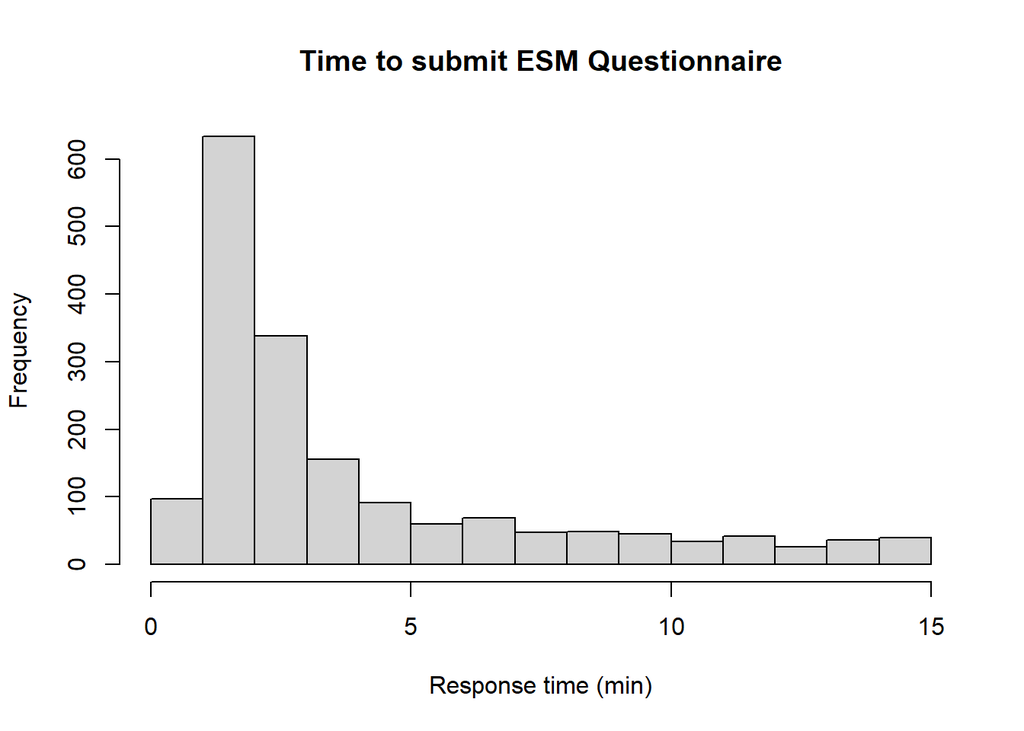

```r
hist(as.numeric(time2submit)/60,breaks=20,main="Time to submit ESM Questionnaire",xlab="Response time (min)")
```

*Comments:*

## 2.2. RETROdata

Here, we recode `RETROdata`.

### 2.2.1. Variable recoding

We start by selecting and renaming data columns.

```r
# removing unuseful columns
RETROdata[,c("X.","grazie","Network.ID")] <- NULL

# renaming columns
colnames(RETROdata) <- c("gender","age","job",
                         "position", # not used in this work
                         "job.sector",
                         "instr",paste("home",1:5,sep=""), # not used in this work
                         "work.hours",
                         paste("phone",1:6,sep=""), # not used in this work
                         paste("JAWS",1:12,sep=""),
                         paste("CBI",1:7,sep=""),
                         paste("PSI",1:18,sep=""), # not used in this work
                         paste("PSIm",1:18,sep=""), # not used in this work
                         paste("d",1:5,sep=""),
                         paste("OCS",1:6,sep=""), # not used in this work
                         paste("c",1:5,sep=""),
                         paste("DWAS",1:10,sep=""), # not used in this work
                         "ID","OS","START","SUBMIT")

# selecting considered variables
RETROdata <-
  RETROdata[,c("ID","OS","START","SUBMIT","gender","age","job","job.sector","work.hours", # participant info & demos
               paste("JAWS",1:12,sep=""),paste("CBI",1:7,sep=""), # job strain (job-related aff. wellb. & burnout)
               paste("d",1:5,sep=""),paste("c",1:5,sep=""))] # job stressors (demand & control)
```

Then, we recode all categorical variables.

```r
# OS (iOS, Android, other)
RETROdata[RETROdata$ID=="Clmr1958" | RETROdata$ID=="ATLG1958" | RETROdata$ID=="DVMC1950" |
          RETROdata$ID=="PRIZZY88", "OS"] <- levels(as.factor(RETROdata$OS))[3] # filling empty values based on ESMdata
RETROdata[RETROdata$ID=="SBAT1949", "OS"] <- levels(as.factor(RETROdata$OS))[4]
RETROdata$OS <- as.factor(gsub("Con sistema ANDROID Samsung, HUAWEI, ASUS, Xiaomi ecc.","Android", # recoding levels
                               gsub("Con sistema iOS iPhone","iOS",
                                    gsub("Altro es. Microsoft phone -&gt; VEDERE NOTA","other",
                                         gsub("[()]","",RETROdata$OS)))))

# gender (F, M)
RETROdata$gender <- as.factor(substr(RETROdata$gender,1,1))

# job sector (Private, Public)
RETROdata$job.sector <- as.factor(gsub("Privato","Private",gsub("Pubblico","Public",RETROdata$job.sector)))

# categorical variables as factor
RETROdata[,c("ID","OS","gender","job.sector")] <- lapply(RETROdata[,c("ID","OS","gender","job.sector")],as.factor)
```

### 2.2.2. Compliance information

Second, we use the `RETRO.compl` function to add information on participants’ **compliance** (encoded in the `"Compliance.csv"` file), to remove **double responses**, and to recode wrongly encoded participants’ `ID` values.

**Show RETRO.compl**

```r
RETRO.compl <- function(data,compliance){ require(plyr)

  # ID recoding
  cat("Excluding 2 pilot responses") # removing pilot responses
  data <- data[!(data$ID=="Prova_ValentinaRossi"),]
  data <- data[!(data$ID=="provaBianca"),]
  data$ID <- gsub("Magg1948","MAGG1948",data$ID) # incorrectly encoded IDs
  data$ID <- gsub("05101985","5101985",data$ID)
  data[!is.na(data$ID)&data$ID=="ANMA1938"&data$job=="Psicologa","ID"] <- "ANIMA1938"
  data[!is.na(data$ID)&data$ID=="MCVD1959"&as.character(data$START)=="2019-05-21 16:12:01","ID"] <- "MCVD19592"
  data[!is.na(data$ID)&data$ID=="mrlv1950","ID"] <- "mrlv19502"
  data$ID <- gsub(" ","",data$ID)
  data$ID <- gsub("Ciao","",data$ID)
  cat("\n\nRecoding 2 participant with identical ID (siblings?)") # siblings
  data[!is.na(data$ID) & data$ID=="LFAI1940"&data$gender=="M","ID"] <- "LFAI19402"

  # merging with compliance.file
  compliance$ID <- gsub("mag-48","MAGG1948",compliance$CODICE) # fixing incorrect ID
  data <- plyr::join(data,compliance,type="full",by="ID")
  data <- data[order(data$ID),]
  rownames(data) <- 1:(nrow(data))

  # fixing respRate variable
  data$respRate <- NA
  data[,c("X1survey","X1day","X3days")] <- lapply(data[,c("X1survey","X1day","X3days")],as.character)
  for(i in 1:nrow(data)){
    if(is.na(data[i,"X1survey"]) | (!is.na(data[i,"X1survey"]) & data[i,"X1survey"] == "")){ data[i,"X1survey"] <- 0
    } else { data[i,"X1survey"] <- 1 }
    if(is.na(data[i,"X1day"]) | (!is.na(data[i,"X1day"]) & data[i,"X1day"] == "")){ data[i,"X1day"] <- 0
    } else { data[i,"X1day"] <- 1 }
    if(is.na(data[i,"X3days"]) | (!is.na(data[i,"X3days"]) & data[i,"X3days"] == "")){ data[i,"X3days"] <- 0
    } else { data[i,"X3days"] <- 1 }
    if(is.na(data[i,"noQs"]) | (!is.na(data[i,"noQs"]) & data[i,"noQs"] == "")){ data[i,"noQs"] <- 0 }
    data[i,"respRate"] <- sum(as.numeric(data[i,c("X1survey","X1day","X3days")]))}
  # data[,c("ID","respRate","X1survey","X1day","X3days")] # sanity check
  data$X1day <- data$X1survey <- data$X3days <- data$N <- data$CODICE <- NULL # removing unuseful varibles
  data$respRate <- as.factor(data$respRate)

  # excluding 3 participants with no responses to both questionnaires
  cat("\n\nExcluding 3 participant with no responses to both questionnaires") # siblings
  data <- data[!(data$noQs==1&data$respRate==0),]

  # printing compliance information
  cat("\n\nTotal No. of participants = ",nrow(data),", of which:\n - ",
      nrow(data[data$noQs==0&as.numeric(data$respRate)>0,])," (",
      round(100*nrow(data[data$noQs==0&as.numeric(data$respRate)>0,])/nrow(data),2),
      "%) responded to BOTH RETROdata & at least 1 ESMdata\n - ",
      nrow(data[data$noQs==0&data$respRate==0,])," (",
      round(100*nrow(data[data$noQs==0&data$respRate==0,])/nrow(data),2),
      "%) responded to RETROdata BUT NOT to any ESMdata\n - ",
      nrow(data[data$noQs==1&as.numeric(data$respRate)>0,])," (",
      round(100*nrow(data[data$noQs==1&as.numeric(data$respRate)>0,])/nrow(data),2),
      "%) responded to at least 1 ESMdata BUT NOT to RETROdata\n\nAmong the first ",
      nrow(data[data$noQs==0&as.numeric(data$respRate)>0,])," participants:\n- ",
      nrow(data[data$noQs==0&as.numeric(data$respRate)>1,])," (",
      round(100*nrow(data[data$noQs==0&as.numeric(data$respRate)>1,])/nrow(data),2),
      "%) responded to BOTH RETROdata & at least 1 ESMdata per day\n- ",
      nrow(data[data$noQs==0&data$respRate==3,])," (",
      round(100*nrow(data[data$noQs==0&data$respRate==3,])/nrow(data),2),
      "%) responded to BOTH RETROdata & at least 3 ESMdata per day\n\n",
      sep="")

  # updating ID levels
  data$ID <- as.factor(as.character(data$ID))

  return(data[,c("ID","gender","age","OS","respRate","noQs","START","SUBMIT",
                 colnames(data)[7:(ncol(data)-2)])])}
```

```r
# processing data
RETROdata <- RETRO.compl(RETROdata,compliance=read.csv2("S5_Compliance.csv"))
```

```
## Excluding 2 pilot responses
##
## Recoding 2 participant with identical ID (siblings?)
##
## Excluding 3 participant with no responses to both questionnaires
##
## Total No. of participants = 211, of which:
##  - 202 (95.73%) responded to BOTH RETROdata & at least 1 ESMdata
##  - 36 (17.06%) responded to RETROdata BUT NOT to any ESMdata
##  - 9 (4.27%) responded to at least 1 ESMdata BUT NOT to RETROdata
##
## Among the first 202 participants:
## - 166 (78.67%) responded to BOTH RETROdata & at least 1 ESMdata per day
## - 114 (54.03%) responded to BOTH RETROdata & at least 3 ESMdata per day
```

```r
RETROdata$noQs.1 <- NULL # double column

# sanity check (211, 211)
cat(nrow(RETROdata),"observations from",nlevels(RETROdata$ID),"participants")
```

```
## 211 observations from 211 participants
```

*Comments:*

### 2.2.3. Recoding jobs

Here, the `job.recode()` function is used to recode the open-ended `job` item responses by using the **ISCO-08 classification of occupations (level 2)** (Ganzeboom, 2010).

**show `job.recode()`**

```r
job.recode <- function(data){ require(labourR); require(data.table); require(magrittr)

  # creating corpus data
  corpus <- data.table(id=data$ID,text=data$job,language="it")
  corpus$text <- gsub(" presso la segreteria didattica del Dipartimento di Psicologia Generale","", # remove sensitive info
                      gsub("POSTE ITALIANE","",gsub("CMP di FIUMICINO","",corpus$text)))
  languages <- unique(corpus$language) # language classes

  # first screening based on the labourR::classify_occupation() function
  suggestions <- lapply(languages, function(lang) {
    classify_occupation(corpus=corpus[corpus$language==lang],lang=lang,isco_level=2,num_leaves=10)
    }) %>% rbindlist
  corpus <- plyr::join(corpus,suggestions,by="id",type="left")

  # adjusting automatic classification based on manual screening
  corpus[corpus$text%in%c("impiegato pubblico","Impiegato","impiegato","impiegata","Impiegata","Impiegato ","IMPIEGATA",
                          "Impiegata ","Impiegata d’ufficio, receptionist ","Impiegato tecnico","Segretaria d'azienda ",
                          "Impiegata presso  con mansioni operative al ","impegato","Impiegatizio"),"preferredLabel"] <-
    "General and keyboard clerks"
  corpus[corpus$text%in%c("SERVIZI","customer care back office",
                          "lavori di segreteria, archiviazioni pratica, ricevimento clienti  etc\\."),"preferredLabel"] <-
    "Customer services clerks"

  corpus[grep("assegnista",tolower(corpus$text)),"preferredLabel"] <-
    "Science and engineering professionals"
  corpus[corpus$text%in%c("Docente universitario","Data scientist","Assegno di ricerca ","assistente ricercatore",
                          "Postdoc ","Professore Associato - Università di Padova","Ricercatore, Docente, Psicoterapeuta",
                          "Professore universitario","Ricerca accademica","Prof ass dpss","Docente Universitario",
                          "Ricercatore universitario RTDA","Assegno di ricerca",
                          "Post doc in laboratorio di microbiologia","docente universitario"),"preferredLabel"] <-
    "Science and engineering professionals"
  corpus[corpus$text%in%c("Programmatore"),"preferredLabel"] <-
    "Information and communications technology professionals"
  corpus[corpus$text%in%c("Responsabile comunicazione digitale/press","Addetto alla formazione",
                          "Commerciale in un'azienda in campo energetico","Tax advisor","Digital Marketer",
                          "Responsabile di selezione del personale in agenzia per il lavoro","HR SPECIALIST",
                          "Ufficio Risorse Umane","Recruiter",
                          "Responsabile contatti in una società di logistica","Digital Marketer freelance e Youth Worker",
                          "Impiegata e operatore del mercato del lavoro, gestisco e metto in atto azioni di orientamento professionale per disoccupati","Consulente di orientamento professionale","Addetta alla selezione del personale",
                          "Progettazione spazi adibiti a retail e visual merchandising strategico",
                          "grafica pubblicitaria","Responsabile comunicazione digitale e grafica",
                          "Graphic Designer","commercialista"),"preferredLabel"] <-
    "Business and administration professionals"
  corpus[corpus$text%in%c("impiegato amministrativo","Lavoro d’ufficio in Banca","Contabile ammintrativo",
                          "Impiegata amministrativa presso Rai","Impiegata settore fiscale",
                          "Impiegato Amministrativo ","Impiegato Amministrativo",
                          "Impiegato digital marketing","assistente commerciale - customer service",
                          "Lavoro impiegatizio presso la pubblica amministrazione",
                          "lavoro impiegatizio di carattere commerciale, lavoro su progetto",
                          "Sono impiegata amministrativa nella segreteria di un Istituto di riabilitazione",
                          "impiegato amministrativo-contabile "),
         "preferredLabel"] <-
    "Business and administration associate professionals"
  corpus[corpus$text%in%c("attività operativa di cantiere"),"preferredLabel"] <-
    "Building and related trades workers, excluding electricians"
  corpus[corpus$text%in%c("attività editoriale","Coordinatrice Culturale",
                          "Archivista. Attività di censimento documentazione enti pubblici. Coordinamento altri operatori"),"preferredLabel"] <-
    "Legal, social, cultural and related associate professionals"
  corpus[corpus$text%in%c("Praticante in uno studio legale, tirocinante in un ufficio giudiziario"),"preferredLabel"] <-
    "Legal, social, cultural and related associate professionals"
  corpus[corpus$text%in%c("Responsabile di selezione del personale in agenzia per il lavoro",
                          "Risorse umane","responsabile"),"preferredLabel"] <-
    "Administrative and commercial managers"
  corpus[corpus$text%in%c("psicologo","Psicologa","Assistente disabili",
                          "Supporto alla didattica, Psicologo",
                          "Maestro di laboratorio presso un'istituzione psico-pedagogico"),"preferredLabel"] <-
    "Social and religious professionals"
  corpus[corpus$text%in%c("direzione","Direttore Generale","Dirigente"),"preferredLabel"] <-
    "Chief executives, senior officials and legislators"
  corpus[corpus$text%in%c("impiegato, coordinatore  preparazione logistico spedizione macchine per imballo",
                          "manager di un team di 8 persone che si occupa della gestione di dati del sottosuolo per l'industria petrolifera"),"preferredLabel"] <-
    "Production and specialised services managers"
  corpus[corpus$text%in%c("Coordinatore Terapisti","Operatore socio sanitario","Infermiere\n",
                          "Coordinatore  infermieristico"),"preferredLabel"] <-
    "Health professionals"
  corpus[corpus$text%in%c("Maestro di laboratorio ",
                          "Maestro di laboratorio presso un'istituzione psico-pedagogico"),"preferredLabel"] <-
    "Teaching professionals"

  # merging corpus with data
  corpus$ID <- as.factor(corpus$id)
  data <- plyr::join(data,corpus[,c("ID","preferredLabel")],by="ID",type="left")

  # marking excluded jobs as jobOut = TRUE
  data$jobOut <- FALSE
  data[data$job%in%c("attività operativa di cantiere","Maestro di laboratorio ","Infermiere professionale\n",
                     "CUSTOMER SERVICE","Assistente disabili","Operatore socio sanitario",
                     "Infermiere\n","Fotografo\nFarmacista"),"jobOut"] <- TRUE

  # replacing original job with recoded job categories
  data$job <- as.factor(data$preferredLabel)
  data$preferredLabel <- NULL # removing preferredLabel

  # summarizing info
  cat("Recoded job variable into",nlevels(data$job),"categories:\n")
  print(summary(data[!is.na(data$job),"job"]))
  cat("\n\n",nrow(data[data$jobOut==TRUE,]),"cases marked as jobOut (incompatible jobs)")
  return(data) }
```

```r
RETROdata <- job.recode(RETROdata)
```

```
## Recoded job variable into 19 categories:
##                      Administrative and commercial managers
##                                                          12
## Building and related trades workers, excluding electricians
##                                                           1
##         Business and administration associate professionals
##                                                          32
##                   Business and administration professionals
##                                                          39
##          Chief executives, senior officials and legislators
##                                                           2
##                                    Customer services clerks
##                                                           2
##                                 General and keyboard clerks
##                                                          20
##                                        Health professionals
##                                                           8
##     Information and communications technology professionals
##                                                           8
##                    Legal, social and cultural professionals
##                                                           4
## Legal, social, cultural and related associate professionals
##                                                           5
##                     Numerical and material recording clerks
##                                                           1
##                                    Personal service workers
##                                                           1
##                Production and specialised services managers
##                                                           8
##             Science and engineering associate professionals
##                                                          10
##                       Science and engineering professionals
##                                                          38
##                          Social and religious professionals
##                                                           4
##                      Stationary plant and machine operators
##                                                           3
##                                      Teaching professionals
##                                                           4
##
##
##  8 cases marked as jobOut (incompatible jobs)
```

```r
# sanity check (211, 211)
cat(nrow(RETROdata),"observations from",nlevels(RETROdata$ID),"participants")
```

```
## 211 observations from 211 participants
```

### 2.2.4. Response times

Finally, we check the time required to fill the preliminary questionnaire based on time stamp variables.

```r
# START and SUBMIT as POSIXct
RETROdata$START <- as.POSIXct(as.character(RETROdata$START))
RETROdata$SUBMIT <- as.POSIXct(as.character(RETROdata$SUBMIT))

# conmputing response times (minutes)
time2submit <- difftime(RETROdata$SUBMIT,RETROdata$START,units="mins")
time2submit[!is.na(time2submit)&time2submit>40] # extreme cases
```

```
## Time differences in mins
##  [1]   58.95000   69.60000  136.83333   53.98333   95.95000   70.00000
##  [7]  320.10000   40.58333  146.43333   58.03333   41.55000  227.08333
## [13]   42.71667  154.11667   79.58333   66.33333   72.40000   44.68333
## [19]   51.45000   84.68333 1848.28333   55.38333
```

```r
time2submit <- time2submit[!is.na(time2submit)&time2submit<40] # excluding 22 extreme cases from the computation
mean(time2submit); sd(time2submit)
```

```
## Time difference of 17.62167 mins
```

```
## [1] 7.706317
```

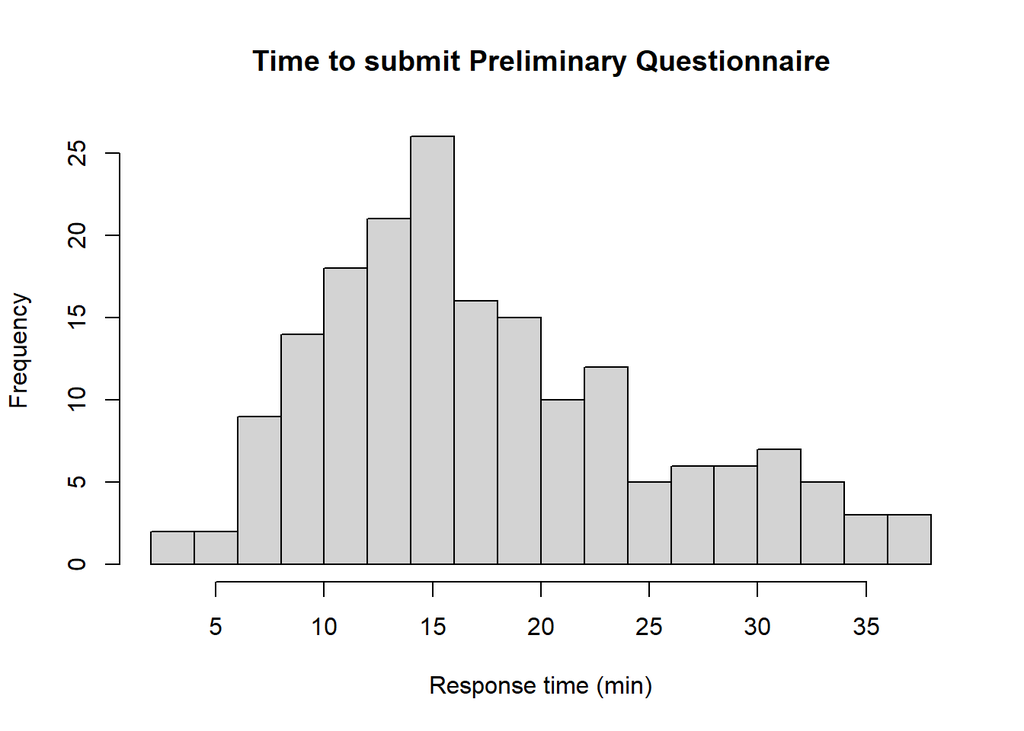

```r
hist(as.numeric(time2submit),breaks=20,main="Time to submit Preliminary Questionnaire",xlab="Response time (min)")
```

*Comments:*

# 3. Data merging

Here, we merge the ESMdata and RETROdata datasets to be used for data analysis.

First, we use the `IDrecode()` function to recode wrongly indicated `ID` values in the `ESMdata` (i.e., most but not all characters corresponded between `ESMdata` and `RETROdata`).

**show IDrecode**

```r
IDrecode <- function(data){
  # correcting wrongly reported IDs
  data$ID <- gsub("05101985","5101985",data$ID)
  data$ID <- gsub("ACLS1955 ","ACLS1955",data$ID)
  data$ID <- gsub("BAFC1922 ","BAFC1922",data$ID)
  data$ID <- gsub("Adfcr49","ADFCR1949",data$ID)
  data$ID <- gsub("Asst42","ASST1945",data$ID)
  data$ID <- gsub("LBMM1958","BLMM1958",data$ID)
  data$ID <- gsub("CRG16","CGT16",data$ID)
  data$ID <- gsub("SGAMOR51","CSAM1951",data$ID)
  data$ID <- gsub("ZFBR50","FZBR50",data$ID)
  data$ID <- gsub("GBPR1944","GBRP1944",data$ID)
  data$ID <- gsub("LCPP1945","LCPP1944",data$ID)
  data$ID <- gsub("LFMI1965","LFMDI1965",data$ID)
  data$ID <- gsub("MGRB1964","MRLV19502",data$ID)
  data$ID <- gsub("Ugiila17L","UCGZ1956",data$ID)
  data$ID <- gsub("Andrea89","VTGF1966",data$ID)
  data$ID <- gsub("LFPT1955","LFPT54",data$ID)
  data$ID <- gsub("GNCP1974","GMCP74",data$ID)
  data$ID <- gsub("PCAN1953","PCAN1935",data$ID)
  data$ID <- gsub("PPCG1961","PPGC1961",data$ID)
  return(data) }
```

```r
ESMdata <- IDrecode(ESMdata)
```

Then, we check for differences in terms of participants’ ID between the two datasets, and we rename variables with the same label.

```r
# checking differences
RETROid <- toupper(levels(as.factor(as.character(RETROdata[RETROdata$respRate!=0,
                                                           "ID"])))) # selecting those that responded to 1+ ESM form
ESMid <- toupper(levels(as.factor(as.character(ESMdata$ID)))) # selectng everybody
for(i in 1:length(RETROid)){ if(RETROid[i] %in% ESMid) next
  else print(RETROid[i])} # showing cases with RETROdata but not ESMdata ID (0)
for(i in 1:length(ESMid)){ if(ESMid[i] %in% RETROid) next
  else print(ESMid[i])} # showing cases with ESM but not RETROdata ID (0)

# renaming variables
colnames(RETROdata)[which(colnames(RETROdata)=="gender")] <- "gender.RETRO" # changing label for sanity check

# IDs in capital letters
RETROdata$ID <- as.factor(toupper(RETROdata$ID)) # only those who answered to at least 1
ESMdata$ID <- as.factor(toupper(ESMdata$ID))
```

Finally, we can merge the two datasets.

```r
# merging
ESMdata <- plyr::join(ESMdata,RETROdata[,c(1:which(colnames(RETROdata)=="work.hours"),ncol(RETROdata))],by="ID",type="full")

# sanity check (different gender between prelQS and ESM)
levels(as.factor(as.character(ESMdata[!is.na(ESMdata$gender)&
                                        !is.na(ESMdata$gender.RETRO)&ESMdata$gender!=ESMdata$gender.RETRO,"ID"]))) # 2 cases
```

```
## [1] "BDRB1955" "MFPW1957"
```

```r
# sanity check (different OS between prelQS and ESM)
levels(as.factor(as.character(ESMdata[!is.na(ESMdata$os)&!is.na(ESMdata$OS)&
                                    as.character(ESMdata$os)!=as.character(ESMdata$OS),c("ID")]))) # 2 cases
```

```
## [1] "LPTB1929" "SOMC57"
```

```r
ESMdata$gender <- ESMdata$gender.RETRO # keeping only RETRO gender
ESMdata$gender.RETRO <- NULL
colnames(RETROdata)[2] <- "gender"
ESMdata$OS <- NULL # keeping only ESM os
```

*Comments:*

- Now, the `ESMdata` dataset includes the demographic and occupational information collected with the preliminary questionnaire, and the information on participants’ compliance. In both cases, the variables assume identical values in each row corresponding to a given participant.
- in only two cases, participants selected the protocol corresponding to a different gender than what they indicated in the preliminary questionnaire (we trust the latter)
- in only two cases, participants reported the wrong OS in the preliminary questionnaire

# 4. Data anonymization

Although data were collected anonymously, an identification code `ID` was self-created by the participants to link the responses between the preliminary questionnaire and the ESM forms. Since this code was created based on personal information (e.g., mother’s year of birth), here we recode `ID` values as `SXXX` so that such information will not be available for future users of our data, in compliance with the GDPR.

```r
# saving IDs
IDs <- data.frame(ID=unique(c(levels(ESMdata$ID),levels(RETROdata$ID))))

# creating new fully anonymized values
IDs$anID <- NA
for(i in 1:nrow(IDs)){ id <- paste("S",i,sep="")
  if(nchar(id)>2){ if(nchar(id)>3){ IDs[i,"anID"] <- id } else { IDs[i,"anID"] <- gsub("S","S0",id) }
  } else { IDs[i,"anID"] <- gsub("S","S00",id) }}
IDs$anID <- as.factor(IDs$anID)
head(IDs$anID) # showing examples
```

```
## [1] S001 S002 S003 S004 S005 S006
## 211 Levels: S001 S002 S003 S004 S005 S006 S007 S008 S009 S010 S011 S012 ... S211
```

```r
# replacing ID values with anID values
ESMdata <- plyr::join(ESMdata,IDs,by="ID",type="left")
ESMdata$ID <- ESMdata$anID
RETROdata <- plyr::join(RETROdata,IDs,by="ID",type="left")
RETROdata$ID <- RETROdata$anID
ESMdata$anID <- RETROdata$anID <- NULL

# sanity check (2015, 211)
cat("ESMdata:",nrow(ESMdata),"observations from",nlevels(ESMdata$ID),"participants")
```

```
## ESMdata: 2015 observations from 211 participants
```

```r
cat("RETROdata:",nrow(RETROdata),"observations from",nlevels(RETROdata$ID),"participants")
```

```
## RETROdata: 211 observations from 211 participants
```

# 5. Data dictionary

Here, we sort the columns and provide a data dictionary for the processed `ESMdata` and `RETROdata` datasets.

## 5.1. ESMdata

```r
# selecting and sorting columns
ESMdata <- ESMdata[,c("ID",colnames(ESMdata)[3:which(colnames(ESMdata)=="SubmissionTimestamp")],
                      colnames(ESMdata)[which(colnames(ESMdata)=="v1"):which(colnames(ESMdata)=="c3")],# ESM variables
                      "gender","age","job","jobOut","job.sector","work.hours", # demographic variables
                      "noQs","respRate")] # response rate info

str(ESMdata)
```

```
## 'data.frame':    2015 obs. of  36 variables:
##  $ ID                 : Factor w/ 211 levels "S001","S002",..: 1 1 1 1 1 1 1 1 1 1 ...
##  $ os                 : Factor w/ 2 levels "Android","iOS": 2 2 2 2 2 2 2 2 2 2 ...
##  $ day                : num  1 1 1 1 2 2 2 3 3 3 ...
##  $ day.of.week        : int  1 1 1 1 3 3 3 5 5 5 ...
##  $ within.day         : num  2 3 4 7 3 6 7 3 4 6 ...
##  $ SurveyType         : Factor w/ 2 levels "baseline","work": 2 2 2 2 2 2 2 2 2 2 ...
##  $ RunTimestamp       : POSIXct, format: "2018-12-03 10:22:29.818" "2018-12-03 12:05:17.028" ...
##  $ SubmissionTimestamp: POSIXct, format: "2018-12-03 10:24:34.655" "2018-12-03 12:07:35.108" ...
##  $ v1                 : num  4 3 2 2 3 3 3 2 2 3 ...
##  $ v2                 : num  3 4 4 4 3 4 4 3 4 4 ...
##  $ v3                 : num  5 4 2 4 3 5 3 2 4 3 ...
##  $ t1                 : num  6 2 2 3 4 3 4 3 3 3 ...
##  $ t2                 : num  1 2 2 5 2 4 2 6 4 2 ...
##  $ t3                 : num  2 3 2 3 3 1 2 2 1 2 ...
```

[output cut: 22 more lines]

**Data structure**

- `ID` = participant’s anonymized identification code
- `os` = participant’s phone operating system (`iOS` or `Android`)
- `day` = day of participation (1, 2 or 3)
- `day.of.week` = weekday (1 = Monday, 3 = Wednesday, 5 = Friday)
- `within.day` = scheduled questionnaire within day (from 1 to 7)
- `SurveyType` = type of ESM questionnaire (“baseline” or “work”)
- `RunTimestamp` and `SubmissionTimestamp` = date and time of ESM questionnaire initiation and submission

**ESM ratings**

- `v1` - `f3` = Multidimensional Mood Questionnaire (MDMQ) items measuring Negative Valence, Tense Arousal, and Fatigue
- `WHAT` = work sampling item asking to indicate the type of work task performed in the last 10 min
- `HOW` = work sampling item asking to indicate the mean of work used in the last 10 min
- `WHOM` = work sampling item asking to indicate the people involved in the task
- `nPeople` = work sampling item asking to indicate the total number of people present during the task
- `d1` - `d4` = Task Demand Scale (TDS) items
- `c1` - `c3` = Task Control (TCS) items

**Demographics** (also included in `RETROdata`)

- `gender` = participant’s gender (`M` or `F`)
- `age` = participant’s age (years)
- `job` = participant’ job recoded by using ISCO-08 categories
- `jobOut` = logical variable equal to `TRUE` for those participants with a job not compatible with our inclusion criteria
- `job.sector` = participant’s job sector (`Private` or `Public`)
- `work.hours` = participant’s weekly work hours

**Inclusion criteria** (also included in `RETROdata`)

- `noQs` = indicating if the participant filled the preliminary questionnaire (0) or not (1)
- `RRate` = participant’s response rate

## 5.2. RETROdata

```r
# selecting and sorting columns
RETROdata <- RETROdata[,c("ID","gender","age","job","jobOut","job.sector","work.hours",
                          paste("JAWS",1:12,sep=""),paste("CBI",1:7,sep=""),
                          paste("d",1:5,sep=""),paste("c",1:5,sep=""),"noQs","respRate")]

str(RETROdata)
```

```
## 'data.frame':    211 obs. of  38 variables:
##  $ ID        : Factor w/ 211 levels "S001","S002",..: 1 2 176 3 4 5 6 7 177 8 ...
##  $ gender    : Factor w/ 2 levels "F","M": 2 2 2 1 1 2 1 2 1 1 ...
##  $ age       : int  33 29 44 42 40 43 59 41 33 33 ...
##  $ job       : Factor w/ 19 levels "Administrative and commercial managers",..: 16 16 14 7 3 16 4 2 1 1 ...
##  $ jobOut    : logi  FALSE FALSE FALSE FALSE FALSE FALSE ...
##  $ job.sector: Factor w/ 2 levels "Private","Public": 2 2 1 1 2 2 1 1 1 1 ...
##  $ work.hours: int  50 50 60 40 50 50 46 55 50 40 ...
##  $ JAWS1     : int  1 5 3 3 3 3 4 3 3 2 ...
##  $ JAWS2     : int  3 5 3 2 2 3 4 3 5 1 ...
##  $ JAWS3     : int  1 2 2 2 3 2 4 2 2 1 ...
##  $ JAWS4     : int  1 3 2 2 4 2 5 3 3 1 ...
##  $ JAWS5     : int  4 3 1 3 2 2 4 3 3 1 ...
##  $ JAWS6     : int  4 5 2 2 3 4 3 3 4 2 ...
##  $ JAWS7     : int  3 3 4 2 4 4 2 4 2 3 ...
```

[output cut: 24 more lines]

**Data structure**

- `ID` = participant’s anonymized identification code

**Demographics** (also included in `ESMdata`)

- `gender` = participant’s gender (`M` or `F`)
- `age` = participant’s age (years)
- `job` = participant’ job recoded by using ISCO-08 categories
- `jobOut` = logical variable equal to `TRUE` for those participants with a job not compatible with our inclusion criteria
- `job.sector` = participant’s job sector (`Private` or `Public`)
- `work.hours` = participant’s weekly work hours

**Retrospective ratings**

- `JAWS1` - `JAWS12` = Job-related Affective Wellbeing Scale item responses
- `CBI1` - `CBI7` = Copenhagen Burnout Inventory (work-related burnout dimension) item scores
- `d1` - `d5` = Quantitative Workload Inventory item scores
- `c1` - `c5` = Job Control item scores

**Inclusion criteria** (also included in `RETROdata`)

- `noQs` = indicating if the participant filled the preliminary questionnaire (0) or not (1)
- `RRate` = participant’s response rate

# 6. Data export

Finally, we export the two processed datasets in both .RData and CSV format to be used in the main analyses.

```r
# exporting processed ESMdata
save(ESMdata,file="S5_processedData/ESM_processed.RData")
write.csv(ESMdata,"S5_processedData/ESM_processed.csv")

# exporting processed RETROdata
save(RETROdata,file="S5_processedData/RETRO_processed.RData")
write.csv(RETROdata,"S5_processedData/RETRO_processed.csv")
```

# References

- Ganzeboom, H. B. (2010). International standard classification of occupations ISCO-08 with ISEI-08 scores. Version of July, 27, 2010.
- Xiong, H., Huang, Y., Barnes, L. E., & Gerber, M. S. (2016). Sensus: a cross-platform, general-purpose system for mobile crowdsensing in human-subject studies. Proceedings of the 2016 ACM International Joint Conference on Pervasive and Ubiquitous Computing, 415–426. https://doi.org/10.1145/2971648.2971711

## R packages

Bache, Stefan Milton, and Hadley Wickham. 2022. *Magrittr: A Forward-Pipe Operator for r*. https://CRAN.R-project.org/package=magrittr.

Birk, Matthew A. 2016. *Birk: MA Birk’s Functions*. https://CRAN.R-project.org/package=birk.

Dowle, Matt, and Arun Srinivasan. 2021. *Data.table: Extension of ‘Data.frame‘*. https://CRAN.R-project.org/package=data.table.

Ewing, Mark. 2021. *Mgsub: Safe, Multiple, Simultaneous String Substitution*. https://CRAN.R-project.org/package=mgsub.

Kouretsis, Alexandros, Andreas Bampouris, Petros Morfiris, and Konstantinos Papageorgiou. 2020. *labourR: Classify Multilingual Labour Market Free-Text to Standardized Hierarchical Occupations*. https://github.com/AleKoure/labourR.

Ooms, Jeroen. 2014. “The Jsonlite Package: A Practical and Consistent Mapping Between JSON Data and r Objects.” *arXiv:1403.2805 [Stat.CO]*. https://arxiv.org/abs/1403.2805.

———. 2022. *Jsonlite: A Simple and Robust JSON Parser and Generator for r*. https://CRAN.R-project.org/package=jsonlite.

R Core Team. 2022. *R: A Language and Environment for Statistical Computing*. Vienna, Austria: R Foundation for Statistical Computing. https://www.R-project.org/.

Wickham, Hadley. 2011. “The Split-Apply-Combine Strategy for Data Analysis.” *Journal of Statistical Software* 40 (1): 1–29. https://www.jstatsoft.org/v40/i01/.

———. 2022. *Plyr: Tools for Splitting, Applying and Combining Data*. https://CRAN.R-project.org/package=plyr.

Wickham, Hadley, Romain François, Lionel Henry, and Kirill Müller. 2022. *Dplyr: A Grammar of Data Manipulation*. https://CRAN.R-project.org/package=dplyr.

Wickham, Hadley, and Maximilian Girlich. 2022. *Tidyr: Tidy Messy Data*. https://CRAN.R-project.org/package=tidyr.